# Data_visualization_slidedeck slides

PROJECT BY - TOCHUKWU THEOPHINE UGOMUOH

OVERVIEW OF INVESTIGATION

The focus of this project was to invesgative the cause of loan default which is a financially unwanted scenerio which leads to collapse of banks and other financial institutions

OVERVIEW OF DATASET

The dataset consisted of LoanStatus with an initial total of 113,937 observations/loans. The attributes included loan term, original loan amount, loan term, Debt to income ratio, Occupation borrower's stated monthly income, borrower's Prosper rating as well as many other features such as borrower's employment status, whether they belong to a group, current loan status etc. after datacleaning, a total of 37721 observations were removed due to several data quality issues.

WHAT IS MY MAJOR INTEREST IN THE PROJECT?

my major interest is to find out factors that lead to loan default, which Prosper must avoid in order to remain in business and not incure heavy losses.

UNIVARIATE VISUALIZATION

Graph 1 - Distribution of loan amount

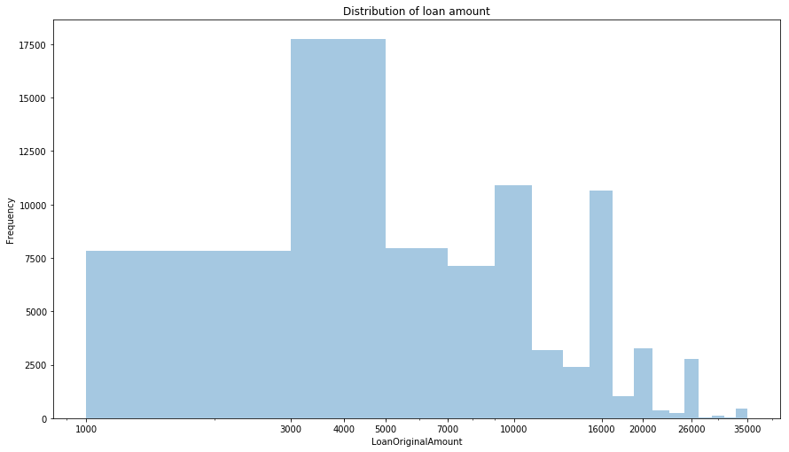

```python
#What is the distribution of the loan amount?
plt.figure(figsize=[14.70, 8.27])
color = sns.color_palette()[0]
bins = np.arange(1000, loan_viz['LoanOriginalAmount'].max() + 2000, 2000)
sns.distplot(loan_viz['LoanOriginalAmount'], bins = bins, kde = False, color = color);
plt.xscale('log')
ticks = [1000, 3000, 4000, 5000, 7000, 10000, 16000, 20000, 26000, 35000]
plt.xticks(ticks, ticks);
plt.title('Distribution of loan amount');
plt.ylabel('Frequency');
```

Graph 3 - Distribution of anuual income of borrowers

NB: In cases like this, monthly or annual income should never be used as a ‘yard stick’ to grant loans because there is a possibility that a borrower could be a business owner who pays himself as he pleases and thus, his pay is not a true reflection of the ‘true’ health of his business. From Graph 3, borrowers with income range of 50000 - 74999 were the highest borrowers, followed by borrowers with income range of 25000 – 49999. This highest group of income earners (100000 + and 75000 – 99999) were 3rd and 4th highest borrowers respectively.

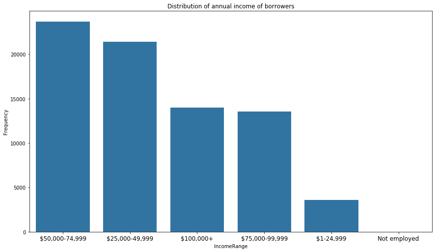

```python
plt.figure(figsize=[14.70, 8.27])
color = sns.color_palette()[0]
order = loan_viz['IncomeRange'].value_counts()
sns.countplot(data = loan_viz, x = 'IncomeRange', color = color, order = order.index);
plt.xticks(fontsize = 12);
plt.ylabel('Frequency');
plt.title('Distribution of annual income of borrowers');
```

Graph 5 - Distribution of ProsperRating (Alpha)

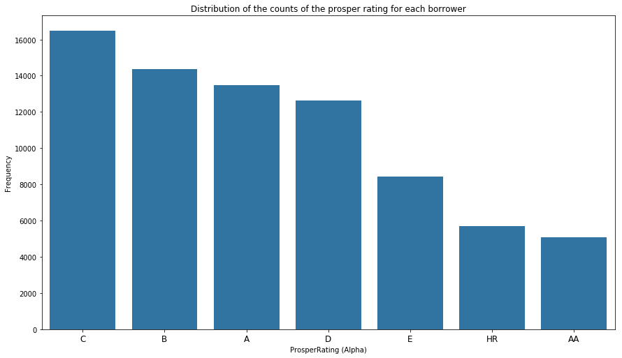

```python
plt.figure(figsize=[14.70, 8.27])
color = sns.color_palette()[0]
order = loan_viz['ProsperRating (Alpha)'].value_counts()
sns.countplot(data = loan_viz, x = 'ProsperRating (Alpha)', color = color, order = order.index);
plt.xticks(fontsize = 12);
plt.ylabel('Frequency');
plt.title('Distribution of the counts of the prosper rating for each borrower');
```

Graph 7

From graph 7, it shows that Prosper has a strong management and implements policy that checkmates against defaulting borrowers. This is evident in the graph as the number of defaulted loans and loans past due combined are a mere 7172 observation which is a mere 9.41% of the total observation.

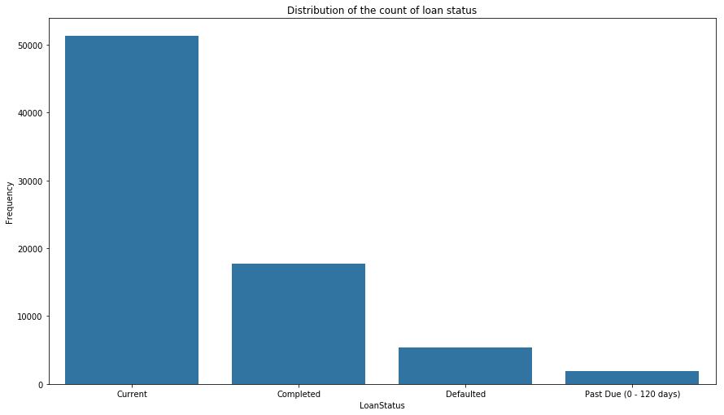

```python
plt.figure(figsize=[14.70, 8.27])
order = loan_viz['LoanStatus'].value_counts()
color = sns.color_palette()[0]
sns.countplot(data = loan_viz, x = 'LoanStatus', color = color, order = order.index);
plt.title('Distribution of the count of loan status');
plt.ylabel('Frequency');
```

BIVARIATE VISUALIZATION

BIVARIATE VISUALIZATION

Graph 10 - Distribution of loan status according to the EmploymentStatus of the borrowers

From Graph 10, as already stated initially, the management policy of Prosper is well to do given that they do not grant as much loans to the borrowers with employment status of ‘retired’, ‘other’, ‘part-time’, ‘self-employed’, ‘Not-employed’. This serves as a preventive measure against ‘potential borrowers’ who cannot repay their loans. It shows the people who are ‘employed’ have lesser financial risks associated with them as they default least.

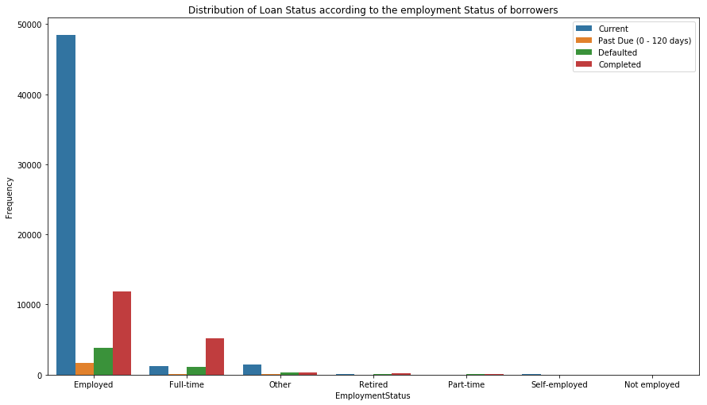

```python
plt.figure(figsize=[14.70, 8.27])
order = loan_viz.groupby('EmploymentStatus')['LoanStatus'].count().reset_index(name = 'LoanStatus').sort_values(by = 'LoanStatus', ascending = False)
sns.countplot(data = loan_viz, x = 'EmploymentStatus', hue = 'LoanStatus', order = order['EmploymentStatus']);
plt.legend(bbox_to_anchor = (1, 1), ncol = 1, loc = 1);
plt.title('Distribution of Loan Status according to the employment Status of borrowers')
plt.ylabel('Frequency');
```

Graph 12 - Distribution of Current_default ratio for each state

From the graph, it shows that states which attracts less risks of defaults, includes:

Mt – Montana HI – Hawaii CO – Colorado WY – Wyoming NM - New Mexico NH - New Hampshire AZ – Arizona NE - Nebraska MA – Massachusetts TX – Texas NY – New York City CA – California AR – Arkansas OR – Orlando NJ - New Jersey DC – Washington DC VT - Vermont IL – Illinois IN – Indiana NOTE: The above states have high current_default ratio States which pose a high default risk, in order of severity includes:

RI – Rhode Island SD – South Dakota NC – North Carolina MO – Missouri TN – Tennessee KY – Kentucky MS – Mississippi ID – Idaho AL – Alabama MD – Maryland LA – Los Angeles FL – Florida

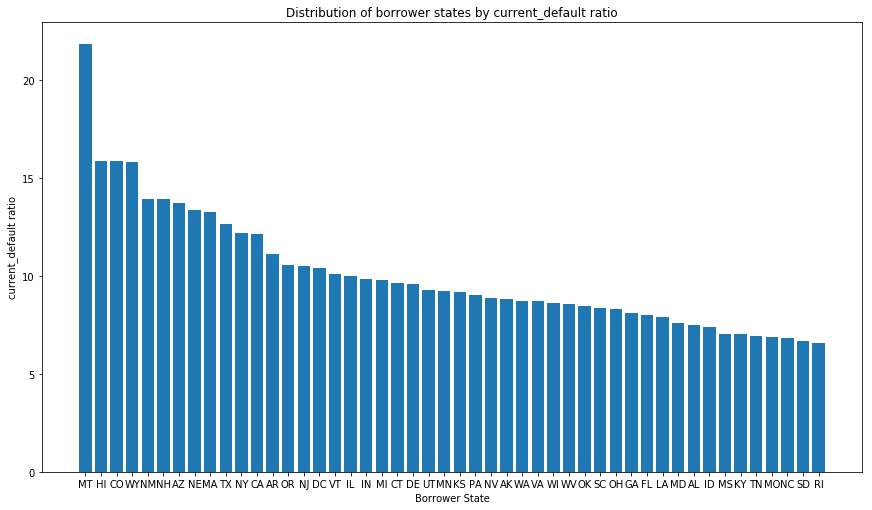

```python
plt.figure(figsize=[14.70, 8.27]);
plt.bar(x = current_default_ratio['BorrowerState'], height = current_default_ratio['LoanStatus']);
plt.xticks(fontsize = 10);
plt.title('Distribution of borrower states by current_default ratio')
plt.ylabel('current_default ratio');
plt.xlabel('Borrower State');
```

Graph 13 - Distribution of loan status by loan term

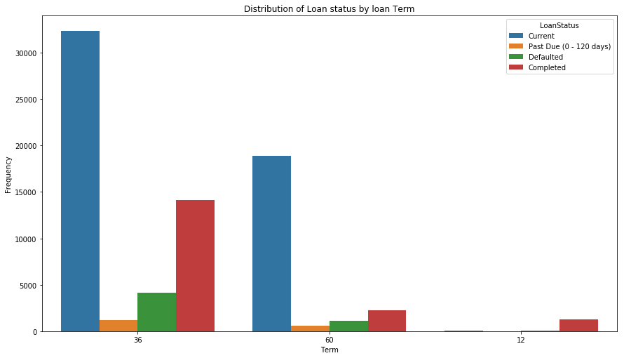

```python
plt.figure(figsize=[14.70, 8.27])
order = loan_viz['Term'].value_counts()
sns.countplot(data = loan_viz, x = 'Term', hue = 'LoanStatus', order = order.index);
plt.title('Distribution of Loan status by loan Term')
plt.ylabel('Frequency');
```

OBSERVATION

Graph 15 - Graph of current_plus_completed_default_ratio vs Prosper loan rating

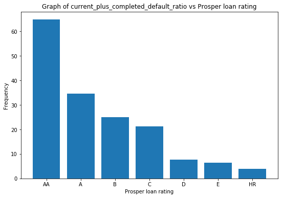

```python
#create new data frames
current = loan_viz.query('LoanStatus == "Current"')
completed  = loan_viz.query('LoanStatus == "Completed"')
default = loan_viz.query('LoanStatus == "Defaulted"')

#Below we get the ((current + completed)  + (default)) ratio; otherwise called current_completed_default ratio
current_plus_completed_default_ratio = (current.groupby('ProsperRating (Alpha)')['LoanStatus'].count() + completed.groupby('ProsperRating (Alpha)')['LoanStatus'].count()) / default.groupby('ProsperRating (Alpha)')['LoanStatus'].count()

current_plus_completed_default_ratio = current_plus_completed_default_ratio.reset_index().sort_values(by = 'LoanStatus', ascending = False)

#Graph of the Current_plus_completed_default_ratio per ProsperRating (Alpha)
plt.figure(figsize = (9, 6))
plt.bar(x = current_plus_completed_default_ratio['ProsperRating (Alpha)'], height= current_plus_completed_default_ratio['LoanStatus']);
plt.title('Graph of current_plus_completed_default_ratio vs Prosper loan rating');
plt.xlabel('Prosper loan rating');
plt.ylabel('Frequency');
```

OBSERVATION

Graph 16 - Graph of current_plus_completed_default_ratio vs Occupation

Graph 16 shows the Occupations to which borrowers are less likely to default. From the graph, we can see that the best professions in order of less financial risks are:

Pilots Student – college graduates Attorney Tradesman/Carpenter Psychologist Engineer – Chemical Scientist Tradesman – Electrician Doctor Architect Analyst Investor Executive Military officer Nurse Computer Programmer Engineer – mechanical Most risky occupations with a strong likelihood to default include: Students – community college Students – college freshman Students – college junior Tradesman – Plumber Homemaker Waiter/waitress Food service Religious Labourer Student – college senior Military enlisted Sales – retail Nurse’s Aide

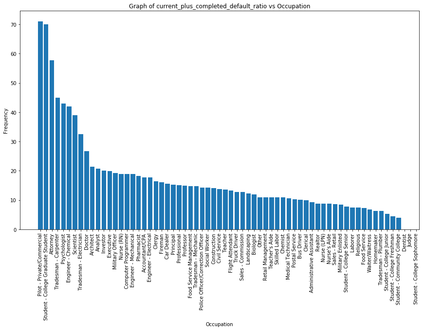

```python
#create new data frames
current = loan_viz.query('LoanStatus == "Current"')
completed  = loan_viz.query('LoanStatus == "Completed"')
default = loan_viz.query('LoanStatus == "Defaulted"')

#Below we get the ((current + completed)  + (default)) ratio; otherwise called current_completed_default ratio
current_plus_completed_default_ratio = (current.groupby('Occupation')['LoanStatus'].count() + completed.groupby('Occupation')['LoanStatus'].count()) / default.groupby('Occupation')['LoanStatus'].count()

current_plus_completed_default_ratio = current_plus_completed_default_ratio.reset_index().sort_values(by = 'LoanStatus', ascending = False)

#Graph of the Current_plus_completed_default_ratio per ProsperRating (Alpha)
plt.figure(figsize=[14.70, 8.27])
plt.bar(x = current_plus_completed_default_ratio['Occupation'], height= current_plus_completed_default_ratio['LoanStatus']);
plt.title('Graph of current_plus_completed_default_ratio vs Occupation');
plt.xlabel('Occupation');
plt.ylabel('Frequency');
plt.xticks(rotation = 90);
```

MULTIVARIATE DISTRIBUTION

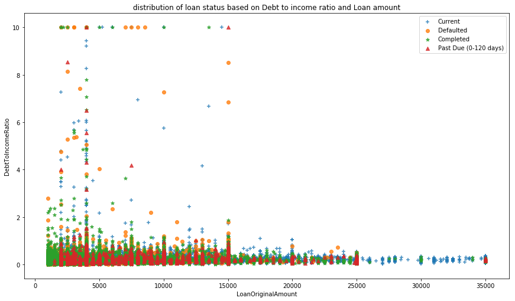

```python
ttype = [['Current', '+'], ['Defaulted', 'o'], ['Completed', '*'], ['Past Due (0 - 120 days)', '^']]

plt.figure(figsize=[14.70, 8.27])
for status, marker in ttype:
    loan_df = loan_viz[loan_viz['LoanStatus'] == status]
    sns.regplot(data = loan_df, x = 'LoanOriginalAmount', y = 'DebtToIncomeRatio', marker = marker, fit_reg = False);

plt.title('distribution of loan status based on Debt to income ratio and Loan amount');
plt.legend(['Current', 'Defaulted', 'Completed', 'Past Due (0-120 days)']);
```